# PEC3 Storytelling: Impacto de las decisiones de los huéspedes

Imanol Pérez Fernández

2024-12-03

# 1 Datos

```r
library(readr)
hotel_bookings_1 <- read_csv("hotel_bookings_1.csv")
```

# 2 Introducción

Este análisis explora patrones en reservas hoteleras basados en datos de un hotel urbano en Lisboa y un resort en la región del Algarve. Utilizamos diversas técnicas de visualización para revelar insights sobre cancelaciones, patrones estacionales y comportamiento del cliente.

# 3 Dos mundos, una historia

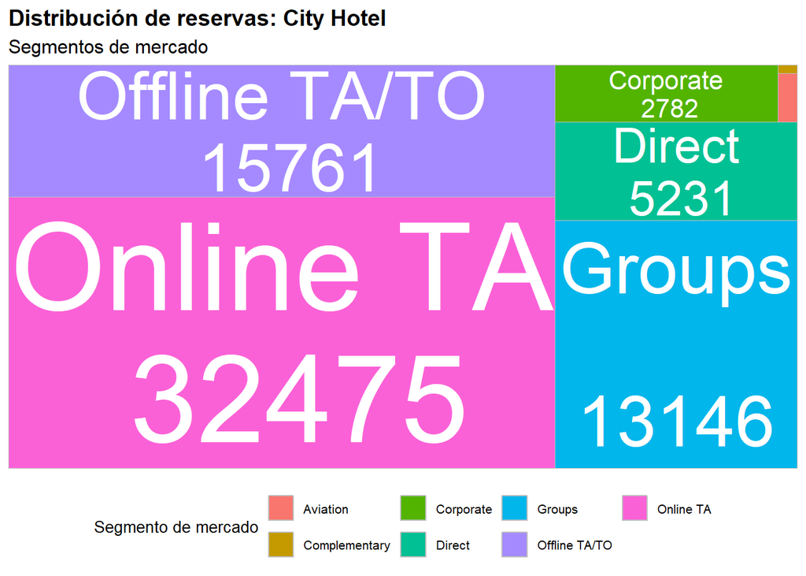

```r
# Cargar las librerías necesarias
library(ggplot2)
library(dplyr)
library(treemapify)
# Preparar los datos iniciales para cada tipo de hotel
treemap_data <- hotel_bookings_1 %>%
  group_by(hotel, market_segment) %>%
  summarise(reservations = n(), .groups = "drop")

# Crear gráfico para City Hotel
city_data <- treemap_data %>% filter(hotel == "City Hotel")

city_treemap <- ggplot(city_data, aes(
  area = reservations,
  fill = market_segment,
  label = paste(market_segment, "\n", reservations)
)) +
  geom_treemap() +
  geom_treemap_text(colour = "white", place = "centre", grow = TRUE, reflow = TRUE) +
  labs(
    title = "Distribución de reservas: City Hotel",
    subtitle = "Segmentos de mercado",
    fill = "Segmento de mercado"
  ) +
  theme_minimal() +
  theme(
    plot.title = element_text(size = 14, face = "bold"),
    plot.subtitle = element_text(size = 12),
    legend.position = "bottom",
    legend.text = element_text(size = 8),
    legend.title = element_text(size = 10)
  )

# Crear gráfico para Resort Hotel
resort_data <- treemap_data %>% filter(hotel == "Resort Hotel")

resort_treemap <- ggplot(resort_data, aes(
  area = reservations,
  fill = market_segment,
  label = paste(market_segment, "\n", reservations)
)) +
  geom_treemap() +
  geom_treemap_text(colour = "white", place = "centre", grow = TRUE, reflow = TRUE) +
  labs(
    title = "Distribución de reservas: Resort Hotel",
    subtitle = "Segmentos de mercado",
    fill = "Segmento de mercado"
  ) +
  theme_minimal() +
  theme(
    plot.title = element_text(size = 14, face = "bold"),
    plot.subtitle = element_text(size = 12),
    legend.position = "bottom",
    legend.text = element_text(size = 8),
    legend.title = element_text(size = 10)
  )

# Mostrar los gráficos individualmente
print(city_treemap)
```

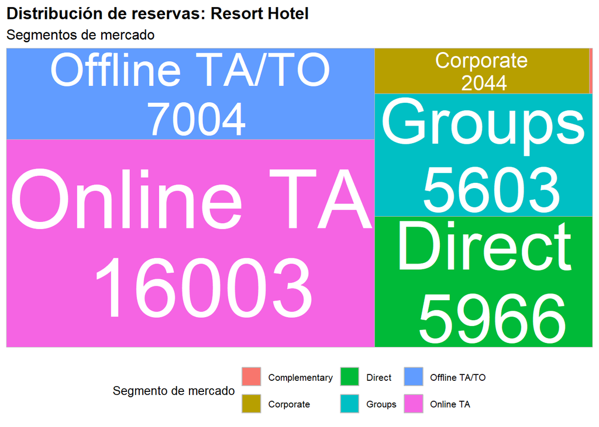

```r
print(resort_treemap)
```

En este caso de estudio hotelero, dos tipos de alojamientos: City Hotel, dominados por viajeros urbanos que prefieren plataformas digitales como OTAs (Online Travel Agencies) (32475 reservas), y los Resort Hotels, enfocados en experiencias de ocio y planificación anticipada, con una distribución más equilibrada entre OTAs (16003), Offline TA/TO (7004) y Direct (5966). Mientras el City Hotel destacan en segmentos corporativos y grupos con alta dependencia de canales digitales, el Resort Hotel prioriza una experiencia personalizada y grupal para eventos y vacaciones. Estas diferencias reflejan cómo cada tipo de hotel adapta su estrategia a las necesidades de sus huéspedes.

# 4 El fantasma de las cancelaciones

[figure not shown]

```r
# Cargar las librerías necesarias
library(dplyr)
library(ggplot2)
library(ggbeeswarm)
library(patchwork)
# Verificar que las columnas utilizadas son del tipo correcto
hotel_bookings_1 <- hotel_bookings_1 %>%
  mutate(
    lead_time = as.numeric(lead_time),
    deposit_type = as.factor(deposit_type),
    market_segment = as.factor(market_segment)
  )

# Preparar los datos para City Hotel
cancel_data_city <- hotel_bookings_1 %>%
  filter(hotel == "City Hotel", is_canceled == 1)

cancel_plot_city <- ggplot(cancel_data_city, aes(
  y = deposit_type, x = lead_time, color = market_segment
)) +
  geom_beeswarm(alpha = 0.6, size = 2) +
  labs(
    title = "Densidad de cancelaciones: City Hotel",
    subtitle = "Por depósito, segmento de mercado y tiempo de cancelación",
    x = "Tiempo anticipado en Días",
    y = "Tipo de Depósito"
  ) +
  theme_minimal() +
  theme(
    legend.position = "right",
    legend.text = element_text(size = 9),
    axis.text.y = element_text(angle = 45, hjust = 1, size = 8),
    plot.title = element_text(size = 14, face = "bold", hjust = 0.5), # Centra el título
    plot.subtitle = element_text(size = 12, hjust = 0.5) # Centra el subtítulo
  ) +
  scale_y_discrete(expand = expansion(mult = c(0.2, 0.2)))

# Preparar los datos para Resort Hotel
cancel_data_resort <- hotel_bookings_1 %>%
  filter(hotel == "Resort Hotel", is_canceled == 1)

cancel_plot_resort <- ggplot(cancel_data_resort, aes(
  y = deposit_type, x = lead_time, color = market_segment
)) +
  geom_beeswarm(alpha = 0.6, size = 2) +
  labs(
    title = "Densidad de cancelaciones: Resort Hotel",
    subtitle = "Por depósito, segmento de mercado y tiempo de cancelación",
    x = "Tiempo anticipado en Días",
    y = "Tipo de Depósito"
  ) +
  theme_minimal() +
  theme(
    legend.position = "right",
    legend.text = element_text(size = 9),
    axis.text.y = element_text(angle = 45, hjust = 1, size = 8),
    plot.title = element_text(size = 14, face = "bold", hjust = 0.5), # Centra el título
    plot.subtitle = element_text(size = 12, hjust = 0.5) # Centra el subtítulo
  ) +
  scale_y_discrete(expand = expansion(mult = c(0.2, 0.2)))

# Combinar ambos gráficos usando patchwork
combined_cancel_plot <- cancel_plot_city / cancel_plot_resort +
  plot_annotation(
    title = "Densidad de cancelaciones por tipo de Hotel",
    subtitle = "Comparativa entre City Hotel y Resort Hotel",
    theme = theme(
      plot.title = element_text(size = 16, face = "bold", hjust = 0.5),
      plot.subtitle = element_text(size = 12, hjust = 0.5)
    )
  )

# Mostrar el gráfico combinado
print(combined_cancel_plot)
```

El Fantasma de las Cancelaciones representa uno de los mayores retos en la gestión hotelera. Los datos revelan que los segmentos OTAs y Offline TA/TO concentran la mayor densidad de cancelaciones tanto en City Hotel como en Resort Hotel, siendo particularmente sensibles las reservas con depósitos Refundable. En City Hotels, el lead time (tiempo anticipado) tiende a ser más largo, lo que aumenta la incertidumbre y dificulta cubrir habitaciones canceladas. Por otro lado, Resort Hotels, con menos reservas totales, enfrentan cancelaciones significativas en Groups, reflejando la volatilidad de los planes grupales. Las políticas de depósito No Refund logran mitigar este problema, aunque podrían disuadir a ciertos segmentos de mercado. Este análisis destaca la necesidad de equilibrar flexibilidad y seguridad financiera para reducir el impacto de las cancelaciones, un desafío constante en ambos tipos hotel.